# R_Junkies Group Project

# Introduction

This project, by **R_Junkies**, is about past airplane crashes, from 1908 to 2017. The project is prepared specifically for BDA 503, 2017, MEF University; course given by [Berk Orbay](http://berkorbay.me/).

## About Group Members

We call ourselves: **R_Junkies**. It represents our humble interest in Data Science. It’s a life-style.

Group members are below (Ladies first):

- [Yağmur Ulutürk Tekten](https://tr.linkedin.com/in/yagmuruluturk)
- [Cem Gürkan](https://tr.linkedin.com/in/cgurkan)
- [Rezan Azizoğlu](https://tr.linkedin.com/in/umut-rezan-azizoglu-b6683146)
- [Semih Tekten](https://tr.linkedin.com/in/semihtekten)

# Gathering Data

Here is the list of datasets and sources we will be using in this project:

- Airplane Crashes Since 1908 - Kaggle [Link](https://www.kaggle.com/saurograndi/airplane-crashes-since-1908)
- Air transport, passengers carried (1970-2016) - World Bank [Link](http://databank.worldbank.org/data/reports.aspx?source=2&series=IS.AIR.PSGR&country=)
- Air transport, registered carrier departures worldwide (1970-2016) - World Bank [Link](http://databank.worldbank.org/data/reports.aspx?source=2&series=IS.AIR.DPRT&country=)

```python
from bs4 import BeautifulSoup
import re
from urllib import request
import datetime
import csv

# Request URL and return response as BeautifulSoup object
def makeBeautifulSoupObject(url):
    requestConn = request.urlopen(url)
    responseHTML = requestConn.read()
    requestConn.close()
    soup = BeautifulSoup(responseHTML, "lxml")
    soup.decode(eventual_encoding="UTF-8")
    return soup

def parseHTML(table_):
    record = {}
    table = BeautifulSoup(str(table_[0]), 'html.parser')

    for tr in table.find_all("tr")[1:]:
        tds = tr.find_all("td")
        # encoding the 'value' string to utf-8 and removing any non-breaking space (HTML Character)
        tmp_str = tds[1].string  # .string.encode('utf-8').replace("&nbsp;", "")
        value = str(tmp_str)  # this is the value- In Column #2 of the HTML table
        key = tds[0].string  # this is the key- In Column #1 of the HTML table
        # print(tds[0])
        if key == "Date:":
            dat = str(value).replace(',', '')
            date = datetime.datetime.strptime(dat, '%B %d %Y')
            record["date"] = date
        elif key == "Time:":
            if not value == '?':
                time = re.sub("[^0-9]", "", value)
                record["time"] = time[0:2] + ":" + time[2:4]
            else:
                record["time"] = ''
        elif key == "Location:":
            if not value == '?':
                record["loc"] = str(value)
            else:
                record["loc"] = ''
        elif key == "Operator:":
            if not value == '?':
                record["op"] = str(value)
            else:
                record["op"] = ''
        elif key == "Flight #:":
            if not value == '?':
                record["flight"] = str(value)
            else:
                record["flight"] = ''
        elif key == "Route:":
            if not value == '?':
                record["route"] = str(value)
            else:
                record["route"] = ''
        elif key == "Registration:":
            if not value == '?':
                record["reg"] = str(value).encode("utf-8")
            else:
                record["reg"] = ''
        elif key == "cn / ln:":
            if not value == '?':
                record["cnln"] = str(value)
            else:
                record["cnln"] = ''
        elif key == "Aboard:":
            if not value == '?':
                s = ' '.join(value.split())
                aboard_ = s.replace('(', '').replace(')', '').split(' ')
                if aboard_[0] != '?':
                    record["aboard_total"] = aboard_[0]
                else:
                    record["aboard_total"] = 'NULL'

                passengers = aboard_[1].replace("passengers:", "")
                if passengers != '?':
                    record["aboard_passengers"] = passengers
                else:
                    record["aboard_passengers"] = 'NULL'

                crew = aboard_[2].replace("crew:", "")
                if crew != '?':
                    record["aboard_crew"] = crew
                else:
                    record["aboard_crew"] = 'NULL'
            else:
                record["aboard_total"] = 'NULL'
                record["aboard_passengers"] = 'NULL'
                record["aboard_crew"] = 'NULL'
        elif key == "Fatalities:":
            if not value == '?':
                s = ' '.join(value.split())
                fatalities_ = s.replace('(', '').replace(')', '').split(' ')

                if fatalities_[0] != '?':
                    record["fatalities_total"] = fatalities_[0]
                else:
                    record["fatalities_total"] = 'NULL'

                passengers = fatalities_[1].replace("passengers:", "")
                if passengers != '?':
                    record["fatalities_passengers"] = passengers
                else:
                    record["fatalities_passengers"] = 'NULL'

                crew = fatalities_[2].replace("crew:", "")
                if crew != '?':
                    record["fatalities_crew"] = crew
                else:
                    record["fatalities_crew"] = 'NULL'
            else:
                record["aboard_total"] = 'NULL'
                record["aboard_passengers"] = 'NULL'
                record["aboard_crew"] = 'NULL'
        elif key == "Ground:":
            if not value == '?':
                record["ground"] = str(value)
            else:
                record["ground"] = 'NULL'
        elif key == "Summary:":
            if not value == '?':
                record["summary"] = str(value).replace('\n','')
            else:
                record["summary"] = ''
        elif key == "AC Type:":
            if not value == '?':
                record["actype"] = str(value)
            else:
                record["actype"] = ''
        else:
            st1 = ''.join(tds[0].string.split()).lower()
            st1 = st1.replace(':', '')
            if not value == '?':
                record[st1] = str(value)
            else:
                record[st1] = "NULL"
    return record

### Main Program ###

# Root URL
rooturl = "http://www.planecrashinfo.com"
# From which year data is taken
start_year = 2009
# to which year data is taken
end_year = 2009

# Create a new file
f = csv.writer(open("Airplane_Crashes_and_Fatalities_Since_2009.csv", "w", newline=''), delimiter=',')
# Header info
f.writerow(["Date", "Time", "Location", "Operator", "Flight #", "Route", "Type", "Registration", "cn/In", "Aboard", "Fatalities", "Ground", "Summary"])

for i in range(start_year, end_year + 1, 1):
    year_start = datetime.datetime.utcnow()
    # appending the path (year) to the url hostname
    # Sample page : http://www.planecrashinfo.com/2008/2008.htm
    newurl = rooturl + "/" + str(i) + "/" + str(i) + ".htm"
    #Get the main page for each year
    soup = makeBeautifulSoupObject(newurl)
    tables = soup.find_all('table')

    #Each page contains the sumamry crash info
    for table in tables:
        # finding the no. of records for the given year
        number_of_rows = len(table.findAll(lambda tag: tag.name == 'tr' and tag.findParent('table') == table))
        number_of_rows = 3

        for j in range(1, number_of_rows, 1):
            # appending the row number to sub-path of the url, and building the final url that will be used for sending http request
            #Sample : http://www.planecrashinfo.com/2008/2008-1.htm
            accident_url = newurl.replace(".htm", "") + "-" + str(j) + ".htm"
            web_record = makeBeautifulSoupObject(accident_url)
            # removing all the boilerplate html code except the data table
            table_details = web_record.find_all('table')
            #Parse table and return crash record
            crashRecord = parseHTML(table_details)
            #Write crash record to file
            f.writerow([crashRecord["date"].strftime('%m/%d/%Y'),
                        crashRecord["time"],
                        crashRecord["loc"],
                        crashRecord["op"],
                        crashRecord["flight"],
                        crashRecord["route"],
                        crashRecord["actype"],
                        crashRecord["reg"],
                        crashRecord["cnln"],
                        crashRecord["aboard_total"],
                        # record["aboard_passengers"],
                        # record["aboard_crew"],
                        crashRecord["fatalities_total"],
                        # record["fatalities_passengers"],
                        # record["fatalities_crew"],
                        crashRecord["ground"],
                        crashRecord["summary"]
                        ])
```

## Airplane Crashes

```r
#Original Kaggle file
apc_raw_to_2009 <- read.csv(file="https://raw.githubusercontent.com/MEF-BDA503/gpj-rjunkies/master/files/project_data/Airplane_Crashes_and_Fatalities_Since_1908.csv", header=TRUE, sep=",")

#Data we crawl from web
apc_raw_from_2009 <- read.csv(file="https://raw.githubusercontent.com/MEF-BDA503/gpj-rjunkies/master/files/project_data/Airplane_Crashes_and_Fatalities_Since_2009.csv", header=TRUE, sep=",")
```

## Passengers Carried

```r
air_psgr <- read.csv(file="https://raw.githubusercontent.com/MEF-BDA503/gpj-rjunkies/master/files/project_data/is_air_psgr_melt.csv", header=TRUE, sep=",", quote="\"", na.strings="NA")
```

## Registered Carrier Departures Worldwide

```r
air_dprt <- read.csv(file="https://raw.githubusercontent.com/MEF-BDA503/gpj-rjunkies/master/files/project_data/is_air_dprt_melt.csv",header=TRUE, sep=",", quote="\"", na.strings="NA")
```

# Data Preprocessing & Cleaning

Here are the necessary libraries. We checked if necessary libraries are not installed properly.

```r
necessary_lib <- c("stringr","tidyverse","ggthemes","grid","gridExtra","scales","tm","SnowballC","wordcloud","RColorBrewer")

# Lets check this necessary libraries against already installed packages.
necessary_lib <- necessary_lib[!(necessary_lib %in% installed.packages())]

if(length(necessary_lib)!=0){
  install.packages(necessary_lib)
}
```

Load necessary libraries

```r
library(stringr) # For string manipulation
library(tidyverse)
library(ggthemes)
library(grid)
library(gridExtra)
library(scales)

library(tm) # for text mining
library(SnowballC) # for text stemming
library(wordcloud) # word-cloud generator
library(RColorBrewer) # color palettes
```

In the next section, we merge the dataset from Kaggle and dataset we crawl in to one dataframe. Kaggle dataset contains partial year 2009 data so we omit year 2009 data.

```r
#Clean data greater than year 2009 data from orginal kaggle file due to amended file contains all 2009 crashes
apc_raw_to_2009 <-  apc_raw_to_2009 %>%
                    mutate(year=format(as.Date(apc_raw_to_2009$Date, format="%m/%d/%Y"),"%Y")) %>%
                    filter(as.numeric(year) < 2009) %>%
                    select(-year)

#Binding data
apc_raw <- rbind(apc_raw_to_2009, apc_raw_from_2009)
```

We first create a new data frame called “apc_clean” which we will manipulate for future analysis.

```r
# New data frame
apc_clean <- apc_raw

# Dimensions
dim(apc_clean)
```

```
## [1] 5543   13
```

```r
# Get an idea of apc_clean columns
str(apc_clean)
```

```
## 'data.frame':    5543 obs. of  13 variables:
##  $ Date        : Factor w/ 5014 levels "01/01/1966","01/01/1970",..: 3297 2372 2699 3184 3682 852 3099 2585 3387 3469 ...
##  $ Time        : Factor w/ 1035 levels "","00:00","00:01",..: 702 200 1 758 385 36 609 1 36 986 ...
##  $ Location    : Factor w/ 4530 levels "","1,200 miles off Dakar, AtlantiOcean",..: 848 123 4179 3388 2294 4059 3117 2288 284 3550 ...
##  $ Operator    : Factor w/ 2708 levels "","A B Aerotransport",..: 1567 1578 1825 1466 1466 1466 1466 1465 1466 1466 ...
##  $ Flight..    : Factor w/ 779 levels "","-","002","004",..: 1 1 2 1 1 1 1 1 1 1 ...
##  $ Route       : Factor w/ 3470 levels ""," - Tegucigalpa - Toncontin",..: 831 2982 1 1 1 1 1 1 1 1 ...
##  $ Type        : Factor w/ 2614 levels "","AÃ©rospatiale SE-210 Caravelle",..: 2419 1145 1032 2433 2435 2446 2434 2148 2439 2438 ...
##  $ Registration: Factor w/ 5184 levels ""," / ","01 / 02 / 03",..: 1 1 1 1 1 1 1 1 1 1 ...
##  $ cn.In       : Factor w/ 3913 levels ""," / 185-5547",..: 171 1 1 1 1 1 1 1 1 1 ...
##  $ Aboard      : int  2 5 1 20 30 41 19 20 22 19 ...
##  $ Fatalities  : int  1 5 1 14 30 21 19 20 22 19 ...
##  $ Ground      : chr  "0" "0" "0" "0" ...
##  $ Summary     : Factor w/ 4959 levels "","31-7952246The pilot reported that he had a rough running engine and was making an emergency landing at Charlo A"| __truncated__,..: 1544 1676 3568 3213 1820 1189 1637 1203 2226 2266 ...
```

There are columns which we can’t use for any analysis. These are: “**Flight..**”, “**Registration**”, “**cn.In**”, “**Ground**”

```r
# Delete "FLight.." column
apc_clean$Flight.. <- NULL

# Delete "Registration" column
apc_clean$Registration <- NULL

# Delete "cn.In" column
apc_clean$cn.In <- NULL

# Delete "Ground" column
apc_clean$Ground <- NULL
```

Beautiful. We dropped unnecessary columns.  
Now it’s time to reshape time-related columns.

```r
# Change date format
apc_clean$Date <- as.Date(apc_clean$Date, format = "%m/%d/%Y")
typeof(apc_clean$Date)
```

```
## [1] "double"
```

```r
# Change & clean time format
apc_clean$Time <- gsub('c:', '', apc_clean$Time)
apc_clean$Time <- gsub('c', '', apc_clean$Time)
apc_clean$Time <- factor(as.character(substr(apc_clean$Time, 1, 2)))
typeof(apc_clean$Time)
```

```
## [1] "integer"
```

```r
# New columns for month & year
apc_clean$Year = factor(format(as.Date(apc_clean$Date, format="%Y/%m/%d"),"%Y"))
apc_clean$Month = factor(format(as.Date(apc_clean$Date, format="%Y/%m/%d"),"%m"))

head(apc_clean$Year)
```

```
## [1] 1908 1912 1913 1913 1913 1915
## 106 Levels: 1908 1912 1913 1915 1916 1917 1918 1919 1920 1921 1922 ... 2017
```

```r
head(apc_clean$Month)
```

```
## [1] 09 07 08 09 10 03
## Levels: 01 02 03 04 05 06 07 08 09 10 11 12
```

We can collect state & city information from “Location” column.

```r
# We add new "State" & "City" column
apc_clean$State <- sapply(apc_clean$Location, as.character)
apc_clean$City <- sapply(apc_clean$Location, as.character)

# Seperate State & City
apc_clean$State <- str_trim(gsub(".*,", "", apc_clean$State))
apc_clean$City <- str_trim(gsub(",.*", "", apc_clean$City))

head(apc_clean$State)
```

```
## [1] "Virginia"           "New Jersey"         "Canada"
## [4] "Over the North Sea" "Germany"            "Belgium"
```

```r
head(apc_clean$City)
```

```
## [1] "Fort Myer"          "AtlantiCity"        "Victoria"
## [4] "Over the North Sea" "Near Johannisthal"  "Tienen"
```

```r
# Delete unnecessary "Location" column
apc_clean$Location <- NULL
```

Very nice. Now we are going to label flights as “Civilian” or “Military”. If “IsMilitary” equals to 1, that means that flight operator is a Military institution, otherwise it is a Civilian flight.

```r
military_keywords <- c("Military", "Army", "Navy")
apc_clean$IsMilitary <- ifelse(grepl(paste(military_keywords, collapse = "|"), apc_clean$Operator),1,0)

# Number of Military Flights
sum(apc_clean$IsMilitary)
```

```
## [1] 814
```

Wonderful. Let’s find out how many passengers survived for each crash.

```r
apc_clean$Survived <- apc_clean$Aboard - apc_clean$Fatalities
head(apc_clean$Survived)
```

```
## [1]  1  0  0  6  0 20
```

We can determine Source, Destination and number of stops from “Route” column.

```r
apc_clean$Source <- gsub(" -.*", "", apc_clean$Route)
apc_clean$Destination <- gsub(".* -", "", apc_clean$Route)
apc_clean$Stops <- str_count(apc_clean$Route,"-")-1

# Number of flights with no Stops
length(which(apc_clean$Stops==0))
```

```
## [1] 3262
```

```r
# Number of flights with no Route information
length(which(apc_clean$Stops<0))
```

```
## [1] 1954
```

```r
# Number of flights with Stops
length(which(apc_clean$Stops>0))
```

```
## [1] 327
```

Lastly, we reordered the columns in apc_clean data frame.

```r
apc_clean <- apc_clean[,c(1,2,9,10,11,12,3,13,4,15,16,17,5,6,7,14,8)]

# Latest structure of apc_clean
str(apc_clean)
```

```
## 'data.frame':    5543 obs. of  17 variables:
##  $ Date       : Date, format: "1908-09-17" "1912-07-12" ...
##  $ Time       : Factor w/ 32 levels ""," 1"," 2"," 9",..: 23 11 1 24 16 6 21 1 6 30 ...
##  $ Year       : Factor w/ 106 levels "1908","1912",..: 1 2 3 3 3 4 4 5 5 5 ...
##  $ Month      : Factor w/ 12 levels "01","02","03",..: 9 7 8 9 10 3 9 7 9 10 ...
##  $ State      : chr  "Virginia" "New Jersey" "Canada" "Over the North Sea" ...
##  $ City       : chr  "Fort Myer" "AtlantiCity" "Victoria" "Over the North Sea" ...
##  $ Operator   : Factor w/ 2708 levels "","A B Aerotransport",..: 1567 1578 1825 1466 1466 1466 1466 1465 1466 1466 ...
##  $ IsMilitary : num  1 1 0 1 1 1 1 1 1 1 ...
##  $ Route      : Factor w/ 3470 levels ""," - Tegucigalpa - Toncontin",..: 831 2982 1 1 1 1 1 1 1 1 ...
##  $ Source     : chr  "Demonstration" "Test flight" "" "" ...
##  $ Destination: chr  "Demonstration" "Test flight" "" "" ...
##  $ Stops      : num  -1 -1 -1 -1 -1 -1 -1 -1 -1 -1 ...
##  $ Type       : Factor w/ 2614 levels "","AÃ©rospatiale SE-210 Caravelle",..: 2419 1145 1032 2433 2435 2446 2434 2148 2439 2438 ...
##  $ Aboard     : int  2 5 1 20 30 41 19 20 22 19 ...
##  $ Fatalities : int  1 5 1 14 30 21 19 20 22 19 ...
##  $ Survived   : int  1 0 0 6 0 20 0 0 0 0 ...
##  $ Summary    : Factor w/ 4959 levels "","31-7952246The pilot reported that he had a rough running engine and was making an emergency landing at Charlo A"| __truncated__,..: 1544 1676 3568 3213 1820 1189 1637 1203 2226 2266 ...
```

You can find references for preprocessing from here.

# Exploratory Analytics of APC

## Explaining the Dataset & Variables

**Dataset**: Airplane crashes from 1908 to 2017. Contains 17 variables, with 5.543 observations.

Here are the variables in our Airplane Crashes dataset and their explanations:

- **Date**: The date of airplane crash.
- **Time**: The time of airplane crash in hh format.
- **Year**: The year of airplane crash.
- **Month**: The month of airplane crash.
- **State**: This field shows the country in which airplane crash happened.
- **City**: This field shows the city in which airplane crash occured.
- **Operator**: This field contains the airline information.
- **IsMilitary**: This field shows whether an operator is a military institution or civilian. It conveys binary results (1=Military, 0=Civilian).
- **Route**: This field contains the departure, arrival and transfer location of the flight. There are both direct and connecting flights.
- **Source**: This field shows the city where the airplane took-off.
- **Destination**: This field shows the destination city.
- **Stops**: This field demonstrates the number of transfer cities for connecting flights.
- **Type**: This field contains the information of the airplane type.
- **Aboard**: This field shows the number of passengers at the time of departure.
- **Fatalities**: This field shows the number of passengers died after airplane crash.
- **Survived**: This field shows the number of passengers survived after airplane crash.
- **Summary**: This field contains information about the airplane crash and possible reasons.

## Objectives

- Understanding statistics and characteristics of past airplane crashes
- Visualizing results of exploratory analysis
- Demonstrating geolocations of airplane crashes on a dynamic map (Using Shiny)
- Forecasting least risky flights for our future travel plans :)
- Developing and demonstrating R, RMarkdown & Shiny skills of **R_Junkies**

## EDA

### Top 10 Airplane Types & Crashes

```r
top_ten_plane <- apc_clean %>%
                  group_by(Type) %>%
                  summarise(Freq = n()) %>%
                  arrange(desc(Freq)) %>%
                  top_n(10)
top_ten_plane$Type <- substr(top_ten_plane$Type,1,19)

top_ten_plane
```

```
## # A tibble: 10 x 2
##                   Type  Freq
##                  <chr> <int>
##  1        Douglas DC-3   334
##  2 de Havilland Canada    86
##  3       Douglas C-47A    74
##  4        Douglas C-47    62
##  5        Douglas DC-4    40
##  6     Yakovlev YAK-40    37
##  7       Antonov AN-26    36
##  8    Junkers JU-52/3m    32
##  9       Douglas C-47B    29
## 10   De Havilland DH-4    28
```

```r
top_ten_mil_plane <- apc_clean %>%
                  filter(IsMilitary==1) %>%
                  group_by(Type) %>%
                  summarise(Freq = n()) %>%
                  arrange(desc(Freq)) %>%
                  top_n(10)
# Slicing long strings
top_ten_mil_plane$Type <- substr(top_ten_mil_plane$Type,1,19)

top_ten_mil_plane
```

```
## # A tibble: 10 x 2
##                   Type  Freq
##                  <chr> <int>
##  1        Douglas C-47    27
##  2     Lockheed C-130H    16
##  3       Antonov AN-26    15
##  4      Boeing KC-135A    15
##  5       Douglas C-47B    14
##  6 Lockheed C-130E Her    14
##  7 Lockheed C-130H Her    13
##  8       Douglas C-47A    12
##  9       Antonov AN-12    10
## 10 Mil Mi-8 (helicopte     9
```

```r
top_ten_civ_plane <- apc_clean %>%
                  filter(IsMilitary==0) %>%
                  group_by(Type) %>%
                  summarise(Freq = n()) %>%
                  arrange(desc(Freq)) %>%
                  top_n(10)
# Slicing long strings
top_ten_civ_plane$Type <- substr(top_ten_civ_plane$Type,1,19)

top_ten_civ_plane
```

```
## # A tibble: 10 x 2
##                   Type  Freq
##                  <chr> <int>
##  1        Douglas DC-3   333
##  2 de Havilland Canada    82
##  3       Douglas C-47A    62
##  4        Douglas DC-4    39
##  5     Yakovlev YAK-40    36
##  6        Douglas C-47    35
##  7    Junkers JU-52/3m    32
##  8   De Havilland DH-4    28
##  9 Cessna 208B Grand C    27
## 10       Douglas DC-6B    26
```

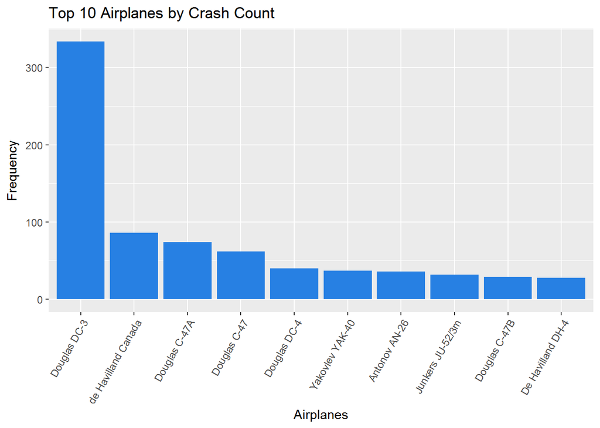

```r
ggplot(top_ten_plane, aes(x=reorder(Type, -Freq), y=Freq)) +
  geom_bar(stat = "identity", fill = "#2780E3") +
  labs(title="Top 10 Airplanes by Crash Count",x="Airplanes",y="Frequency",fill="") +
  theme (axis.text.x=element_text (angle=60,vjust=1, hjust=1))
```

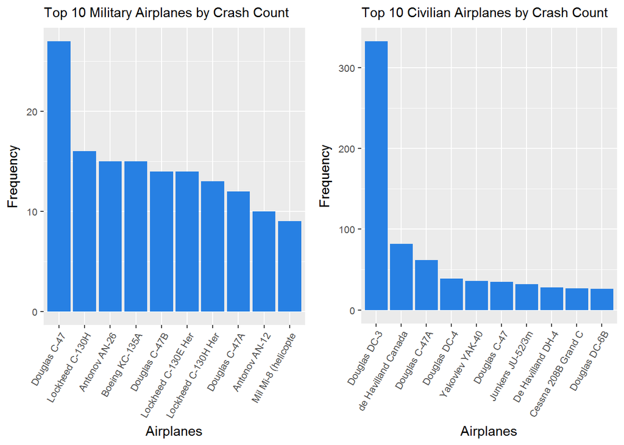

```r
top_ten_mil_plane_plot <- ggplot(top_ten_mil_plane, aes(x=reorder(Type, -Freq), y=Freq)) +
                            geom_bar(stat = "identity", fill = "#2780E3") +
                            labs(title="Top 10 Military Airplanes by Crash Count",x="Airplanes",y="Frequency",fill="") +
                            theme (axis.text.x=element_text (angle=60,vjust=1, hjust=1)) +
                            theme(plot.title = element_text(size=11),
                                  axis.text=element_text(size=8))


top_ten_civ_plane_plot <- ggplot(top_ten_civ_plane, aes(x=reorder(Type, -Freq), y=Freq)) +
                            geom_bar(stat = "identity", fill = "#2780E3") +
                            labs(title="Top 10 Civilian Airplanes by Crash Count",x="Airplanes",y="Frequency",fill="") +
                            theme (axis.text.x=element_text (angle=60,vjust=1, hjust=1)) +
                            theme(plot.title = element_text(size=11),
                                  axis.text=element_text(size=8))

grid.arrange(top_ten_mil_plane_plot, top_ten_civ_plane_plot, ncol=2)
```

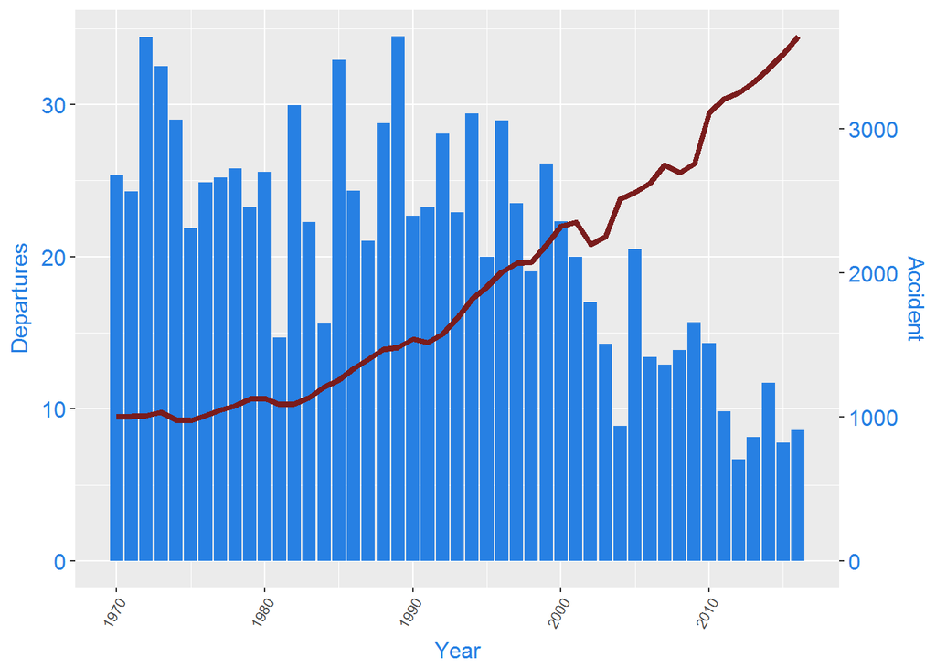

```r
# Total departures in Million

total_dprt <-
  air_dprt %>%
  filter(Time >= 1970 & Time <= 2016) %>%
  mutate(dep_val = ifelse(is.na(Value), 0, Value)) %>%
  group_by(Time) %>% summarize(total_dep=sum(dep_val)/1000000)

# # of Accidents and Fatalities

Acc_fat_data <- apc_clean %>% filter(as.numeric(as.character(Year)) >= 1970 & as.numeric(as.character(Year)) <= 2016) %>%  group_by(Year)%>% summarise(n=sum(ifelse(is.na(Aboard), 0, Aboard)),f=sum(ifelse(is.na(Fatalities), 0, Fatalities)))

# Combining Departures and Accident-Fatality Data

dep_acc_fat <- data.frame(year=total_dprt$Time,
                Departure = total_dprt$total_dep,
                Accident = Acc_fat_data$n,
                Fatality = Acc_fat_data$f,
                Rate = Acc_fat_data$n/total_dprt$total_dep)

# Normalizer for plot

normalizer <- max(dep_acc_fat$Accident)/max(dep_acc_fat$Departure)

ggplot(dep_acc_fat, aes(y=Departure, x=year)) +
  geom_col(aes(y = Accident / normalizer), fill = "#2780E3") +
  geom_line(size=1.5, alpha=1, colour = "#7a1c1c") +
  scale_y_continuous(sec.axis = sec_axis(trans= ~.*normalizer, name = 'Accident')) +
  theme(axis.text.y = element_text(colour="#2780E3", size=12),
    axis.text.x=element_text(angle=60, vjust=1, hjust=1, size=8),
    axis.title=element_text(colour="#2780E3", size=12),
    legend.position = "left" ) +
  labs(y="Departures", x="Year")
```

### Top Civil Operators’ Crashes & Fatalities Over Years

```r
top_six_civ_op_crash <- apc_clean %>%
                        filter(IsMilitary==0) %>%
                        group_by(Operator) %>%
                        summarise(SumCrashes= n()) %>%
                        arrange(desc(SumCrashes))  %>%
                        top_n(6)
top_six_civ_op_fat <- apc_clean %>%
                        filter(IsMilitary==0) %>%
                        group_by(Operator) %>%
                        summarise(SumFats= sum(Fatalities)) %>%
                        arrange(desc(SumFats))  %>%
                        top_n(6)
top_six_civ_op_crash_oy <- apc_clean %>%
                            filter(Operator %in% top_six_civ_op_crash$Operator)  %>%
                            group_by(Operator, Year) %>%
                            summarise(SumFatalities= sum(Fatalities)) %>%
                            arrange(desc(Year), desc(SumFatalities))

top_six_civ_op_fat_oy <- apc_clean %>%
                            filter(Operator %in% top_six_civ_op_fat$Operator)  %>%
                            group_by(Operator, Year) %>%
                            summarise(SumFatalities= sum(Fatalities)) %>%
                            arrange(desc(Year), desc(SumFatalities))

top_six_civ_op_crash
```

```
## # A tibble: 6 x 2
##                              Operator SumCrashes
##                                <fctr>      <int>
## 1                            Aeroflot        179
## 2                          Air France         70
## 3                  Deutsche Lufthansa         65
## 4                            Air Taxi         44
## 5 China National Aviation Corporation         44
## 6                    United Air Lines         44
```

```r
top_six_civ_op_fat
```

```
## # A tibble: 6 x 2
##                     Operator SumFats
##                       <fctr>   <int>
## 1                   Aeroflot    7156
## 2          American Airlines    1421
## 3 Pan American World Airways    1302
## 4           United Air Lines    1021
## 5                    AVIANCA     941
## 6     Turkish Airlines (THY)     891
```

```r
top_six_civ_op_crash_oy
```

```
## # A tibble: 157 x 3
## # Groups:   Operator [6]
##            Operator   Year SumFatalities
##              <fctr> <fctr>         <int>
##  1       Air France   2009           228
##  2         Aeroflot   2008            88
##  3       Air France   2005             0
##  4         Air Taxi   2004             6
##  5         Air Taxi   2002             4
##  6 United Air Lines   2001           109
##  7         Air Taxi   2001             6
##  8       Air France   2000           109
##  9         Air Taxi   2000             3
## 10       Air France   1998            53
## # ... with 147 more rows
```

```r
top_six_civ_op_fat_oy
```

```
## # A tibble: 151 x 3
## # Groups:   Operator [6]
##                  Operator   Year SumFatalities
##                    <fctr> <fctr>         <int>
##  1               Aeroflot   2008            88
##  2 Turkish Airlines (THY)   2003            75
##  3      American Airlines   2001           416
##  4       United Air Lines   2001           109
##  5      American Airlines   2000             1
##  6      American Airlines   1999            11
##  7 Turkish Airlines (THY)   1999             6
##  8       United Air Lines   1997             1
##  9               Aeroflot   1996             2
## 10      American Airlines   1995           160
## # ... with 141 more rows
```

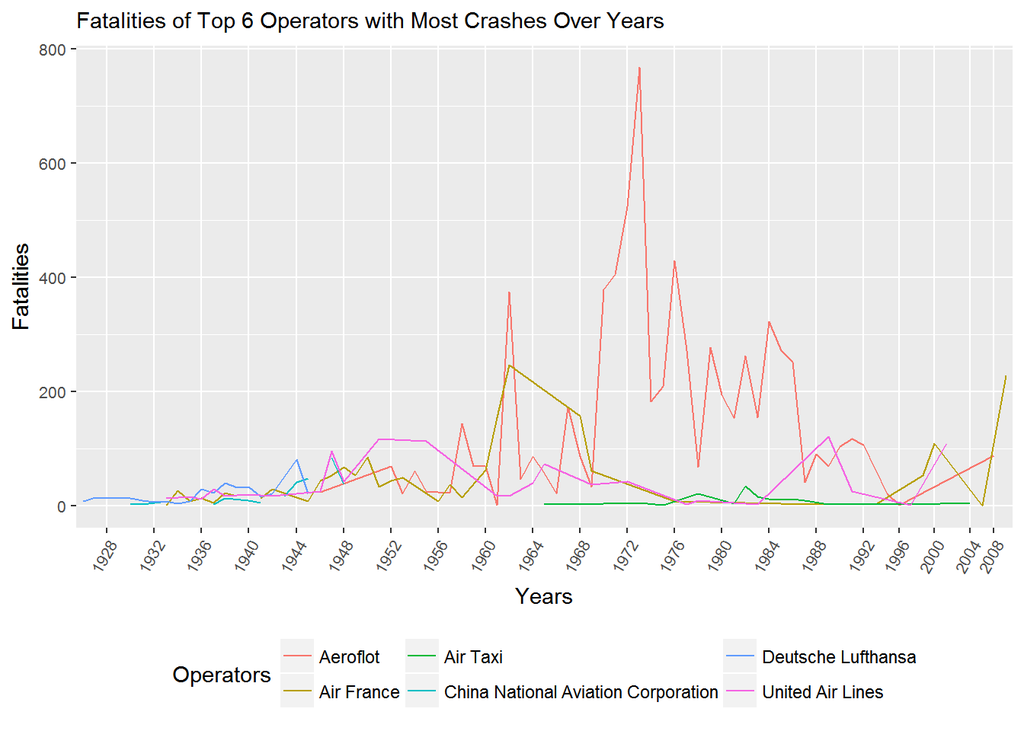

```r
ggplot(top_six_civ_op_crash_oy, aes(x=Year)) +
  geom_line(aes(y=SumFatalities, group = top_six_civ_op_crash_oy$Operator, colour=top_six_civ_op_crash_oy$Operator), size=0.5, alpha=1) +
  ggtitle("Fatalities of Top 6 Operators with Most Crashes Over Years") +
  scale_x_discrete(breaks = levels(top_six_civ_op_crash_oy$Year)[c(T, rep(F, 3))]) +
  theme (axis.text.x=element_text (angle=60,vjust=1, hjust=1)) +
  theme(plot.title = element_text(size=11),
         axis.text=element_text(size=8),
        legend.position="bottom") +
  labs(x = "Years", y = "Fatalities", colour = "Operators")
```

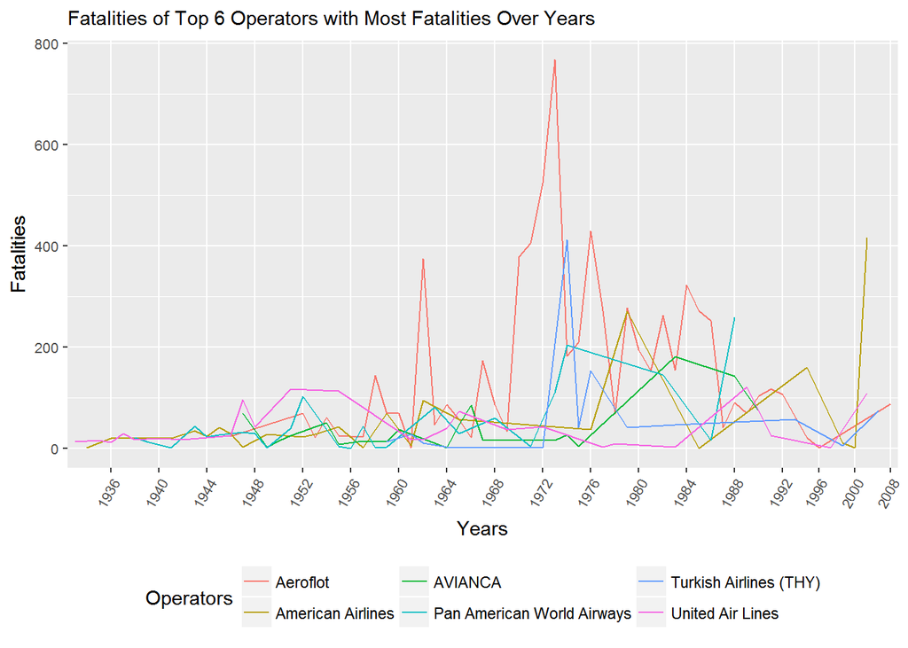

```r
ggplot(top_six_civ_op_fat_oy, aes(x=Year)) +
  geom_line(aes(y=SumFatalities, group = top_six_civ_op_fat_oy$Operator, colour=top_six_civ_op_fat_oy$Operator), size=0.5, alpha=1) +
  ggtitle("Fatalities of Top 6 Operators with Most Fatalities Over Years") +
  scale_x_discrete(breaks = levels(top_six_civ_op_fat_oy$Year)[c(T, rep(F, 3))]) +
  theme (axis.text.x=element_text (angle=60,vjust=1, hjust=1)) +
  theme(plot.title = element_text(size=11),
         axis.text=element_text(size=8),
        legend.position="bottom") +
  labs(x = "Years", y = "Fatalities", colour = "Operators")
```

### Has Survival Rate Increased Over Time?

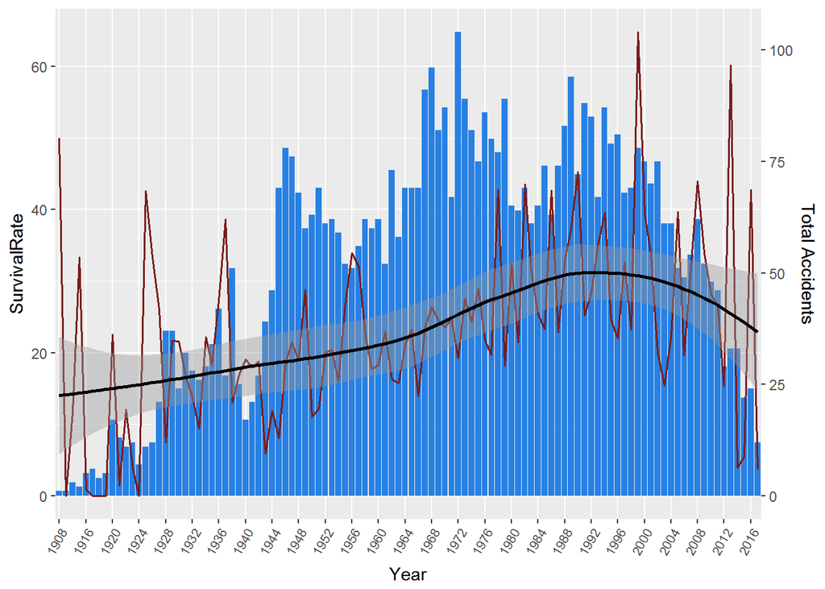

```r
# Survival Rate
dataSurvival <- apc_clean %>%
   filter(as.numeric(as.character(Year)) >= 1900 & Aboard > 0) %>%
   group_by(Year) %>%
   summarize(TotalFatalities=sum(Fatalities),
             TotalAboard=sum(Aboard),
             SurvivalRate=round(100*(TotalAboard-TotalFatalities)/TotalAboard,2),
             Survival = (TotalAboard-TotalFatalities),
             TotalAccident = n())

# Normalizer for dual-y axis
n <- max(dataSurvival$TotalAccident) /max(dataSurvival$SurvivalRate)

ggplot(dataSurvival, aes(y=SurvivalRate, x=Year)) +
   geom_col(aes(y=TotalAccident/n), fill = "#2780E3") +
   geom_line(aes(group = 1), size=0.7, alpha=1, colour = "#7a1c1c") +
   geom_smooth(aes(group = 1), colour = "black") +
   scale_y_continuous(sec.axis = sec_axis(trans= ~.*n, name = 'Total Accidents')) +
   scale_x_discrete(breaks = levels(dataSurvival$Year)[c(T, rep(F, 3))]) +

   theme(axis.text.x=element_text(angle=60, vjust=1, hjust=1, size=8))
```

### Possible Causes of Crashes - Word Cloud

For each accident, there is an explanation in “Summary” column. By looking at this summary information, we tried to visuailize a word cloud.

```r
 text <- apc_clean$Summary

 docs <- Corpus(VectorSource(text))

 toSpace <- content_transformer(function (x , pattern ) gsub(pattern, " ", x))
 docs <- tm_map(docs, toSpace, "/")
 docs <- tm_map(docs, toSpace, "@")
 docs <- tm_map(docs, toSpace, "\\|")

 docs <- tm_map(docs, PlainTextDocument)

 # Convert text to lower case
 docs <- tm_map(docs, content_transformer(tolower))

 # Remove numbers
 docs <- tm_map(docs, removeNumbers)

 # Remove english common stopwords
 docs <- tm_map(docs, removeWords, stopwords("english"))

 # Remove punctuations
 docs <- tm_map(docs, removePunctuation)

 # Eliminate extra white spaces
 docs <- tm_map(docs, stripWhitespace)

 # Text stemming
 docs <- tm_map(docs, stemDocument)

 # Remove possible words that high frequency in text that no meaning for crash reason
 # (After first try in word cloud, we realize that these words are the most frequent one)
 docs <- tm_map(docs, removeWords, c("aircraft", "plane","flight", "crash","crashed"))

 dtm <- TermDocumentMatrix(docs)

 ##Remove sparse terms
 removeSparseTerms(dtm, 0.95)
```

```
## <<TermDocumentMatrix (terms: 38, documents: 5543)>>
## Non-/sparse entries: 20279/190355
## Sparsity           : 90%
## Maximal term length: 8
## Weighting          : term frequency (tf)
```

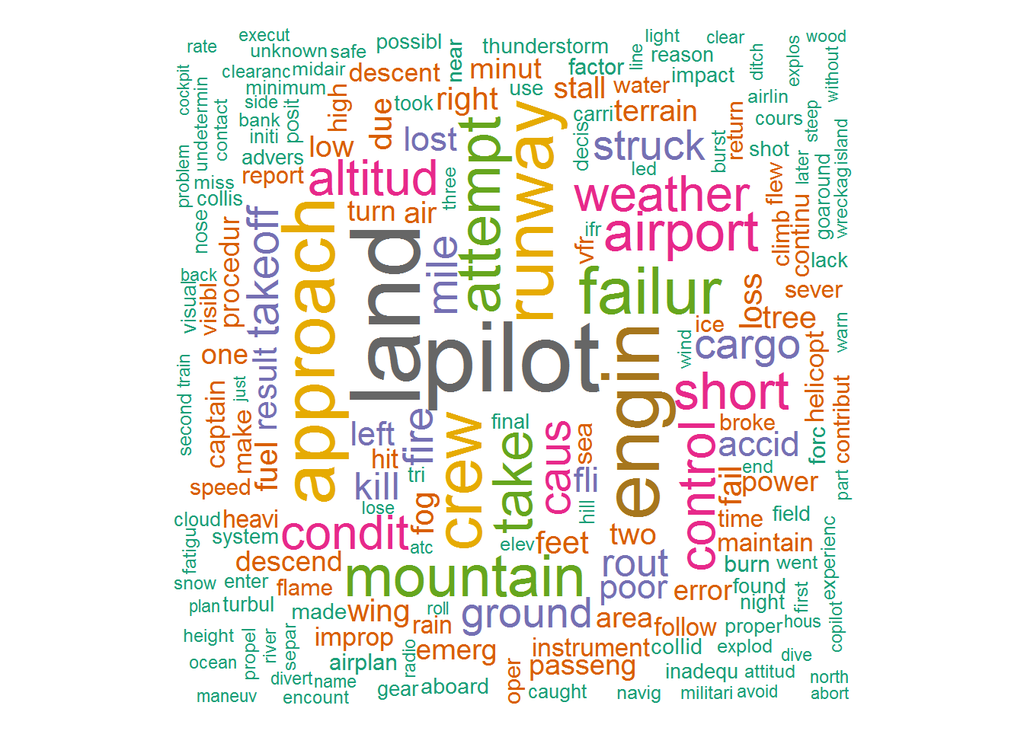

```r
 m <- as.matrix(dtm)
 v <- sort(rowSums(m),decreasing=TRUE)
 d <- data.frame(word = names(v),freq=v)
 #head(d, 10)

 set.seed(1234)
 wordcloud(words = d$word, freq = d$freq, min.freq = 1,
           max.words=200, random.order=FALSE, rot.per=0.35,
           colors=brewer.pal(8, "Dark2"))
```